# Reproductive Health and Education Among Women in Ethiopia: Insights from the 2019 DHS

Yabi Bereket

# **Introduction**

This report will be exploring data collected through the Demographic and Health Survey, administered in Ethiopia in 2019. The report will focus on a subset of variables of interest, to gain better insight on respondents experiences with child birth and their understanding of contraceptives.

# Demographic overview

The tables below looks at relevant demographic information to offer a high level view of information on respondents included in this survey. The variables inspected below are “respage” (respondent age), “urbrural” (rurality), and “highesteduc” (highest education completed). This dataset includes **8,885** total respondents, all **female**. Ages range between **15-49**.

| respage | n | percent |
| --- | --- | --- |
| 15 | 478 | 5.4% |
| 16 | 429 | 4.8% |
| 17 | 333 | 3.7% |
| 18 | 568 | 6.4% |
| 19 | 292 | 3.3% |
| 20 | 557 | 6.3% |
| 21 | 181 | 2.0% |
| 22 | 342 | 3.8% |
| 23 | 283 | 3.2% |
| 24 | 215 | 2.4% |
| 25 | 652 | 7.3% |
| 26 | 232 | 2.6% |
| 27 | 291 | 3.3% |
| 28 | 415 | 4.7% |
| 29 | 162 | 1.8% |
| 30 | 620 | 7.0% |
| 31 | 102 | 1.1% |
| 32 | 190 | 2.1% |
| 33 | 128 | 1.4% |
| 34 | 126 | 1.4% |
| 35 | 470 | 5.3% |
| 36 | 115 | 1.3% |
| 37 | 148 | 1.7% |
| 38 | 212 | 2.4% |
| 39 | 92 | 1.0% |
| 40 | 383 | 4.3% |
| 41 | 58 | 0.7% |
| 42 | 144 | 1.6% |
| 43 | 78 | 0.9% |
| 44 | 51 | 0.6% |
| 45 | 274 | 3.1% |
| 46 | 51 | 0.6% |
| 47 | 73 | 0.8% |
| 48 | 74 | 0.8% |
| 49 | 66 | 0.7% |

A majority of respondents report living in **rural** areas of Ethiopia (67%), and a plurality either say they either have “no education” (41%) or received “primary education” (38%).

| **Characteristic** | **N = 8,885**<sup>1</sup> |
| --- | --- |
| highest educational level |  |
| no education | 3,640 (41%) |
| primary | 3,345 (38%) |
| secondary | 1,149 (13%) |
| higher | 751 (8.5%) |
| type of place of residence |  |
| urban | 2,951 (33%) |
| rural | 5,934 (67%) |

<sup>1</sup> n (%)

# Substantive information

## Exploring age of respondents at first birth

We will first be exploring how old respondents were when having had their first child. The age range for this variable is between 10-44 years old. Rather than displaying each individual age, respondents will be grouped based on this grouping method of age at birth used in a report by the CDC, found here: https://www.cdc.gov/nchs/data/nvsr/nvsr72/nvsr72-01.pdf . *Note*: this variable includes 3,039 NA’s (representing respondents who have not had children), and will be removed from the graph and analysis.

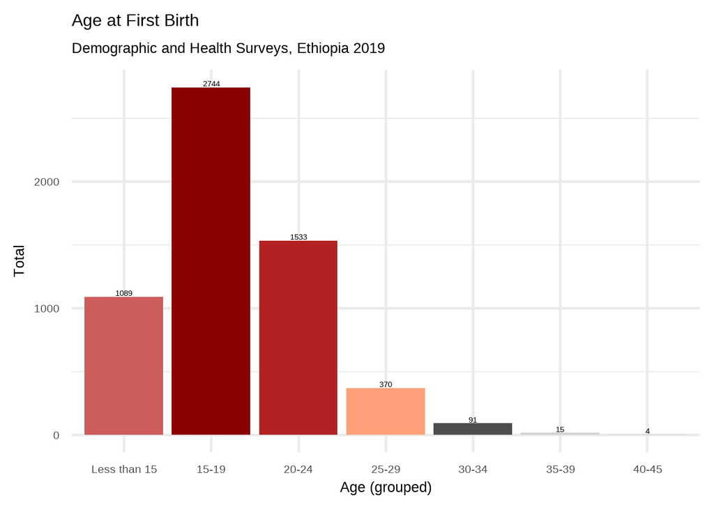

### Interpretation

Based on the graph, the majority of respondents were between 15-19 years old when having had their first child, followed by 20-24, and then less than 15. It appears that as respondents get older, they are less likely to have had their first child by that age. To gain further insight into this graph, the following graph stratifies these results by rurality.

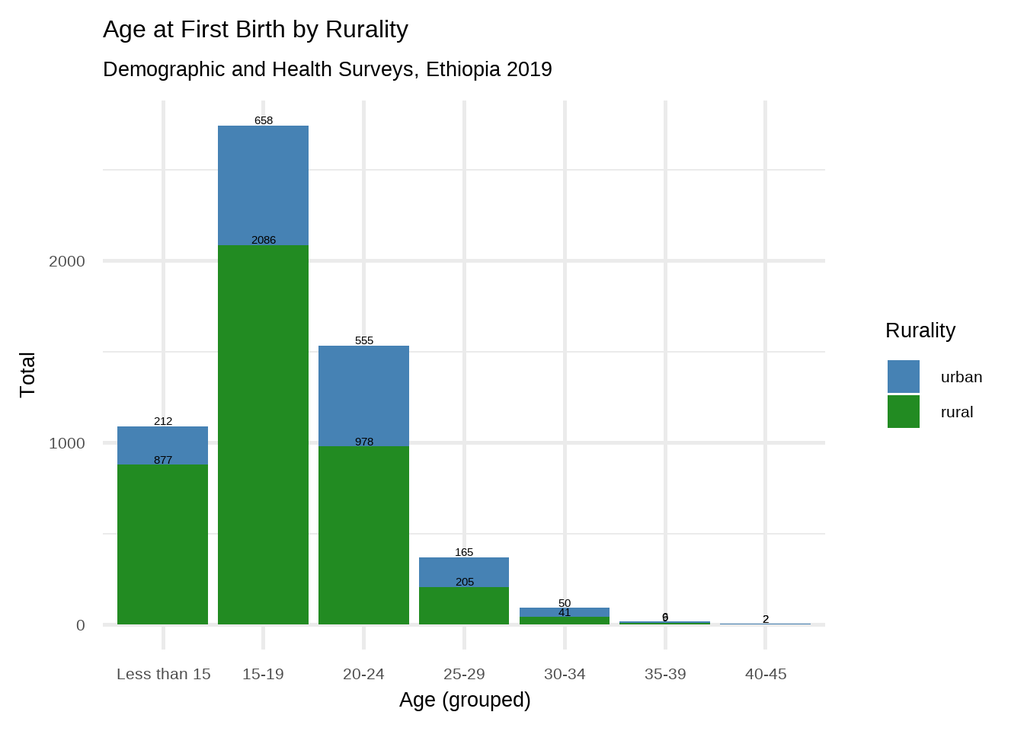

### Interpretation

It appears for the first three age groups, the majority of respondents are from rural regions of the country, with the greatest occurrence of this being for those in the age group 15-19.

## Respondents Knowledge of Contraceptives

The next variable investigates respondents knowledge of different contraceptives, stratified by highest education completed.

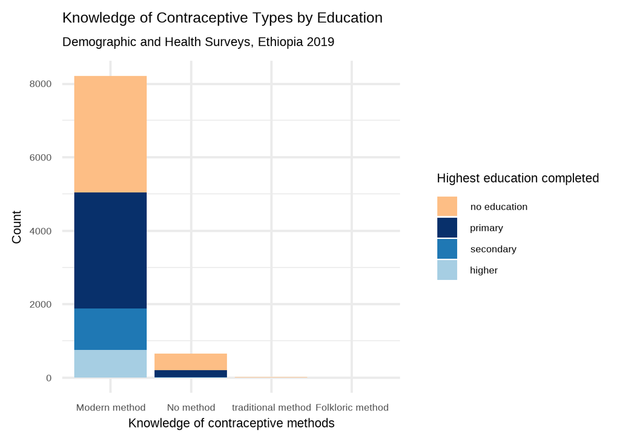

### Interpretation

The graph above looks at respondents knowledge of contraceptives by education level. Based on the graph, a majority of respondents with primary level education and no education demonstrate knowledge of modern contraceptive types. Few respondents report knowing no method, with education levels being either ‘no education’ or ‘primary’ level education.

## Number of children

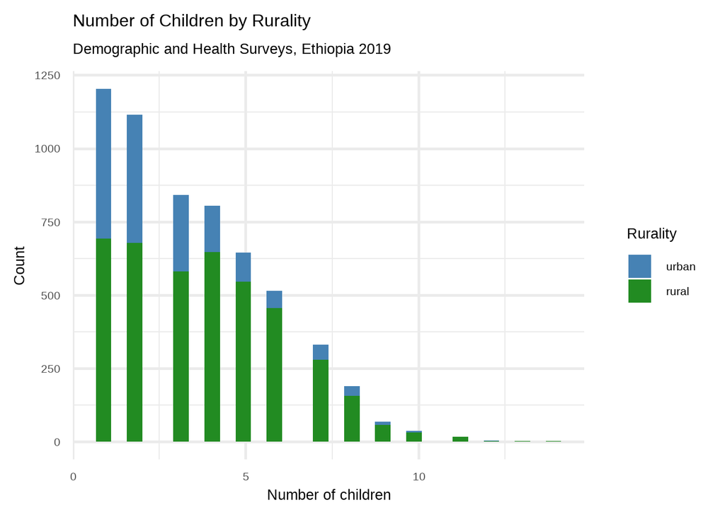

### Interpretation

The number of living children respondents have decrease as the numbers increase on the graph, showing a greater amount report having either 1-5 children. It appears more respondents report being from rural areas of the country compared to urban.

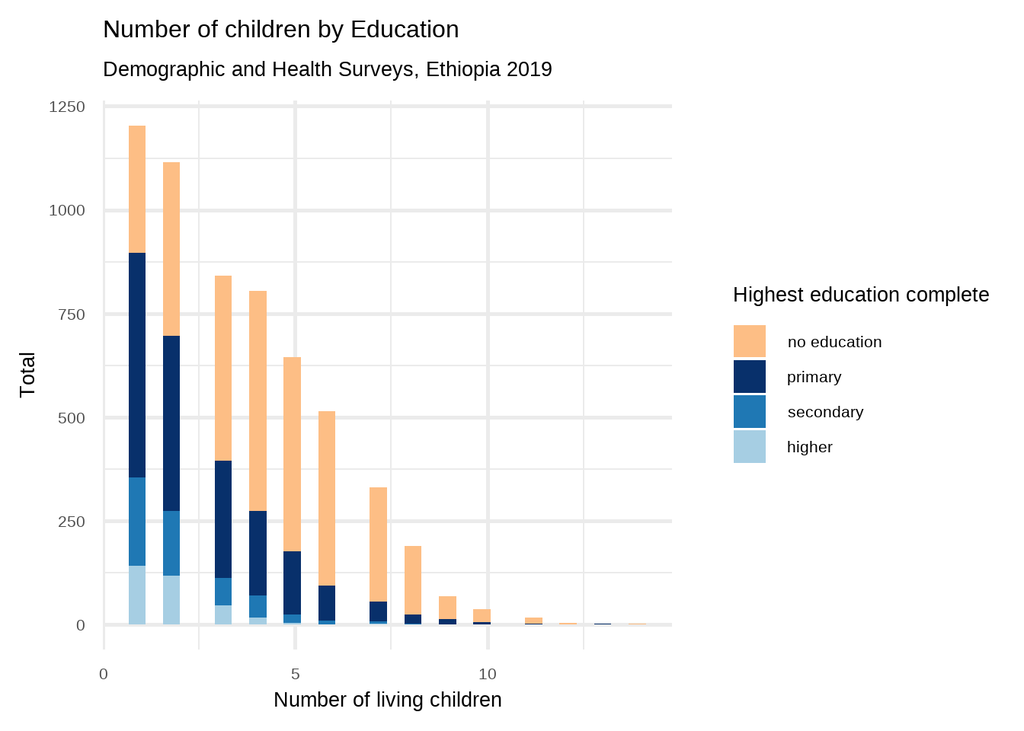

# Conclusion

This report provided an overview of selected demographic and reproductive health variables from the 2019 Ethiopia Demographic and Health Survey. By focusing on respondent age, rurality, education, age at first birth, contraceptive knowledge, and number of children, the analysis offers a clearer picture of women’s reproductive experiences and health knowledge across the country. Findings indicate that most respondents live in rural areas and have limited formal education, with many having their first child between the ages of 15–19. Knowledge of modern contraceptives is relatively high even among those with little or no education, and respondents from rural areas and those with no education are more likely to report having a greater number of children. These insights highlight the importance of targeted health education and family planning interventions, particularly in rural communities and among women with limited educational access.